In this analysis, we are going to determine which of the following variables contributes to the severity of flood - Month of flood - Duration in Days - Centroid X (Latitude) - Centroid Y (Longitude) - Main cause of flood

PCA on flood data was performed on these five variables. We have used the package factoextra is used for the visualization of the principal component analysis results. The below plot contribution of variances in each PC. With more than 80% contribution in PC1 and about 10 % in PC2 , The result of PCA shows that first 2 PCs account for large proportion of variablity. Therefore we can achieve a good dimension reduction in the first 2 PCs.

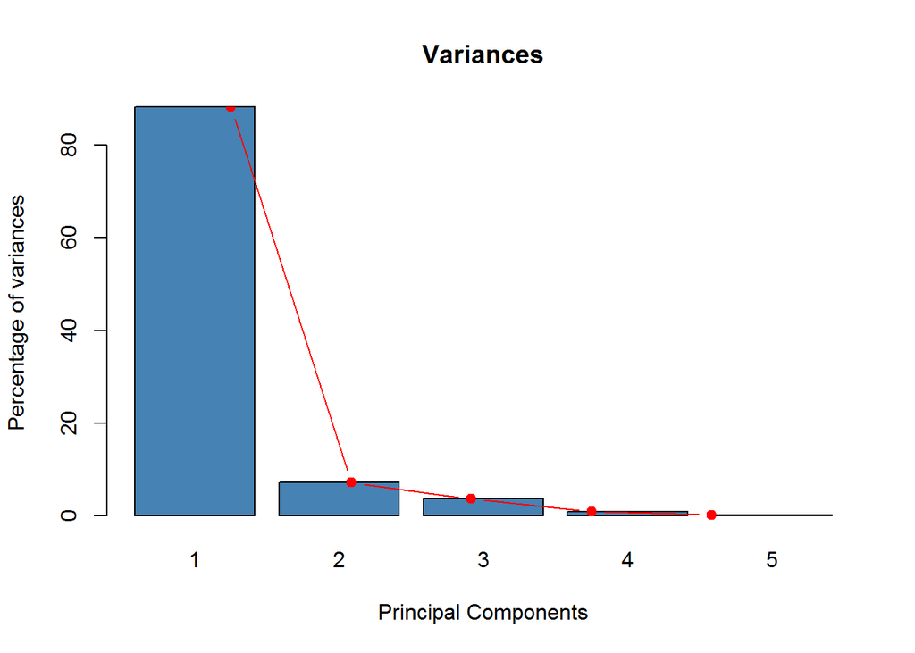

```
##                    PC1         PC2          PC3          PC4           PC5
## Began       0.05742831  -0.4426381   0.17138108 -0.006963295 -3.1139927138
## Duration   -0.06541269   2.6591059 -15.97062582  0.079034938 -0.0401685176
## Lat        79.51219790  -0.9472002  -0.09452269 -0.049715584  0.0046254294
## Long       -3.38189693 -22.4123860  -1.89749688 -0.226225820  0.0565608872
## Main_Cause  0.41179338  -0.6873678   0.10695805  7.755085018 -0.0007070772
```

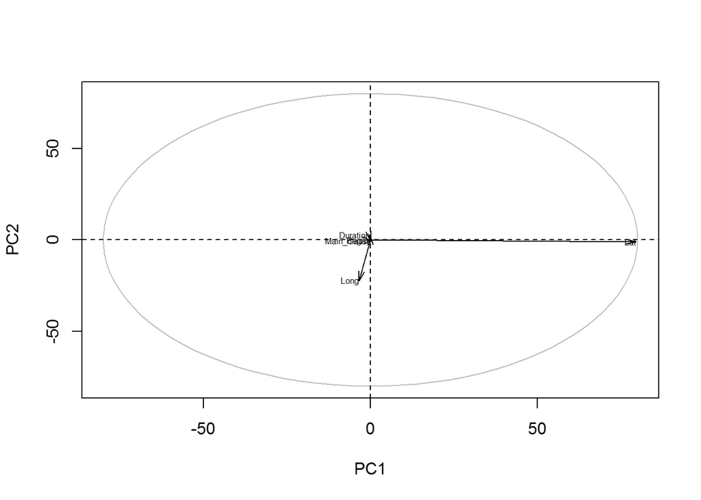

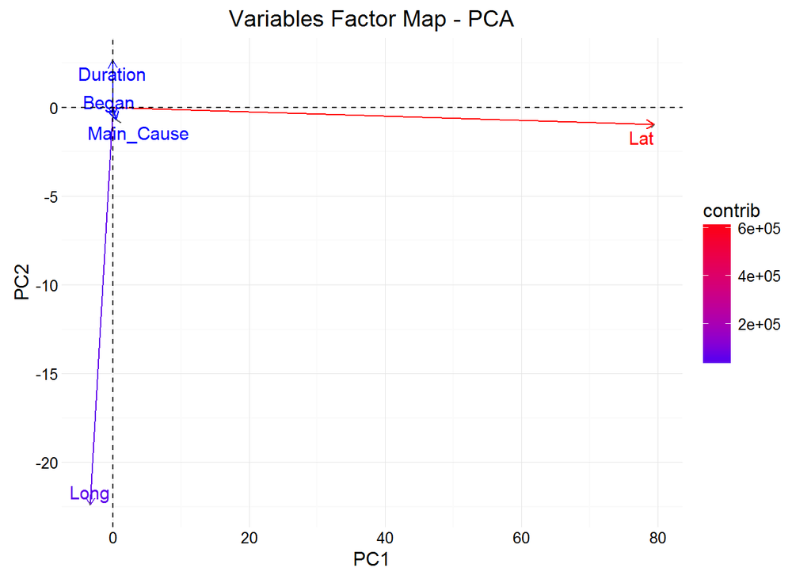

In the above graph , gradient from blue to red indicates increasing contribution in PCA. Clearly variance in Latitude has maximum contribution. By zooming into the graph we can clearly see contirbution other variables.

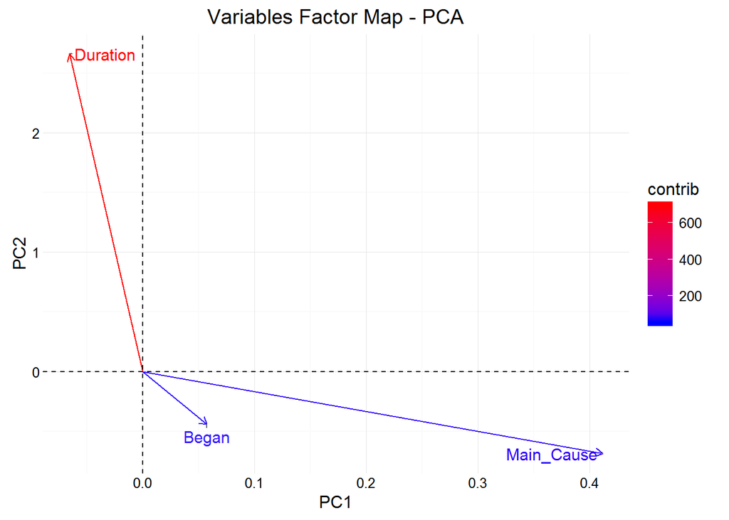

Now we want to determine in which direction different severities of the flood distributed . This can be determined by plotting cluster of flood points.

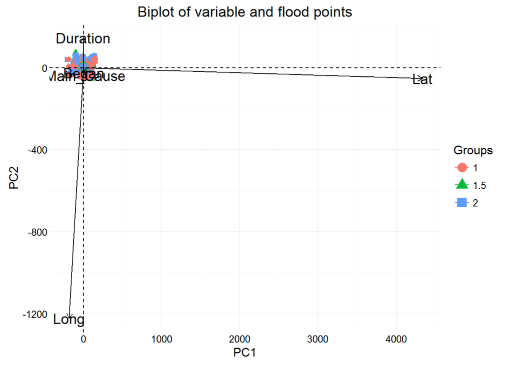

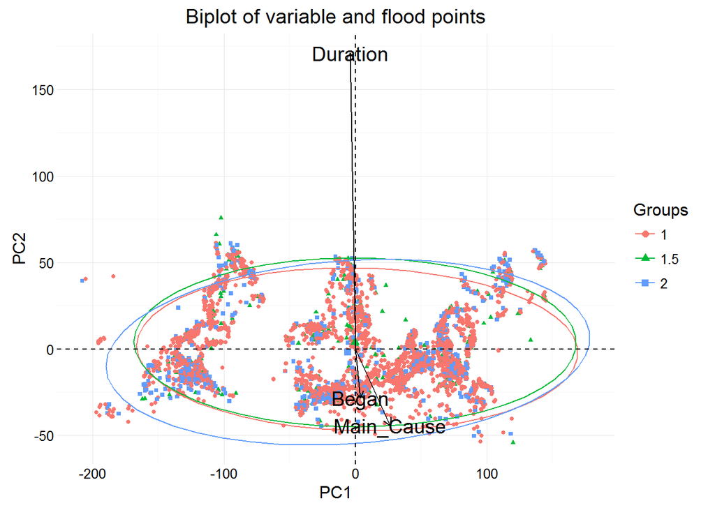